# Using Raster Data in R

# 5 Loading and Saving Rasters

```r
# Choose a Directory where to store the save raster file
#my.file.path = "C:\\TERN\\AusCover_Tut1"
# OLD: my.file.path = "C:\\Users\\uqbblanc\\Documents\\TERN\\01A-Data_TERN\\3-AusCover\\AusCover_Tut1"
my.file.path = "C:\\Users\\uqbblanc\\Documents\\TERN\\04-DSDP_Outputs\\1-Tutorials\\Tut1_UsingRasterDatainR\\NEW_190203"
# or perhaps us
# my.file.path = getwd()
```

## 5.1 Saving Rasters

We can use two functions:

- `writeRaster`: Writes an entire Raster* object to a file in a supported format.
- `writeValues`: Writes chucks (e.g. by row) of a Raster* object to a file in a supported format.

Supported formats include (in parenthesis is the file extension for the format). The last 3 formats cannot store Multi-band rasters. See help on ‘writeRaster’ and ‘writeFormat’ for further details:

- native R ‘raster’ package format (.grd): It conserves the original file names in the individual band names.
- netCDF (.nc): Requires the library `ncdf4`.
- GeoTiff (.tif): Requires the library `rgdal`.
- ENVI .hdr labelled (.envi),
- ESRI hdr. labelled (.bil)
- Erdas Imagine Images (.img)
- ESRI ASCII (.asc)
- SAGA GIS (.sdat),
- IDRISI (.rst).

If argument `prj` is TRUE, the CRS is written to a ‘.prj’ file. This can be useful when writing to a file type that does not store the crs, such as ASCII files.

For multi-layer rasters (RasterStack and RasterBrick objects), individual layers can be stored in the same file or in separate files. When argument `bylayer` is TRUE, layers are saved to separate files. In this case, to name the separate files the user provide naming directions using the argument ‘suffix’:

- A vector with filenames, with as many file names as layers (i.e. names(x))
- A single filename that will get a unique suffix (i.e. a number between 1 and nlayers(x))

```r
# Single layer raster (RasterLayer object)
# ----------------------------------------

# Save a single Layer from a single layer raster (RasterLayer object) in GeoTiff format (requires library 'rgdal')
writeRaster(r2a, filename=paste(my.file.path,"r2a.tif",sep="\\"), format="GTiff", overwrite=TRUE)



# Multi-layer rasters (RasterStack and RasterBrick objects)
# ---------------------------------------------------------

# Save all layers of a RasterStack object in a single file in netCDF format (requires library 'ncdf4')
writeRaster(s2, filename=paste(my.file.path,"s2.nc",sep="\\"), format="CDF", overwrite=TRUE)


# Save individual layers of a RasterBrick object in separate files in native R 'raster' package format
writeRaster(b2,  filename=paste(my.file.path,"b2.grd",sep="\\"),  format="raster", overwrite=TRUE,
                   bylayer=TRUE)
```

## 5.2 Loading Rasters

Loading rasters is done with the same functions that are used to create them from data (i.e. `raster`, `stack`, and `brick`).

Note that when extracting a single layer from a multi-layer raster:

- Argument `layer`is used for extracting the layer from a RasterStack or RasterBrick object or a File.
- Argument `band` is used for extracting the layer from a File (exclusively).

```r
# Single layer raster (RasterLayer object)
# ----------------------------------------


# Load single Layer from a single layer file
r2a.from.r2a.tif = raster(paste(my.file.path,"r2a.tif",sep="\\"))
hasValues(r2a.from.r2a.tif)
```

```
## [1] TRUE
```

```r
inMemory(r2a.from.r2a.tif)
```

```
## [1] FALSE
```

```r
r2a.from.r2a.tif
```

```
## class       : RasterLayer
## dimensions  : 10, 10, 100  (nrow, ncol, ncell)
## resolution  : 2, 3  (x, y)
## extent      : 100, 120, -30, 0  (xmin, xmax, ymin, ymax)
## coord. ref. : +proj=longlat +datum=WGS84 +no_defs +ellps=WGS84 +towgs84=0,0,0
## data source : C:\Users\uqbblanc\Documents\TERN\04-DSDP_Outputs\1-Tutorials\Tut1_UsingRasterDatainR\NEW_190203\r2a.tif
## names       : r2a
## values      : 1, 100  (min, max)
```

```r
r2a.from.r2a.tif[]
```

```
##   [1]   1   2   3   4   5   6   7   8   9  10  11  12  13  14  15  16  17
##  [18]  18  19  20  21  22  23  24  25  26  27  28  29  30  31  32  33  34
##  [35]  35  36  37  38  39  40  41  42  43  44  45  46  47  48  49  50  51
##  [52]  52  53  54  55  56  57  58  59  60  61  62  63  64  65  66  67  68
##  [69]  69  70  71  72  73  74  75  76  77  78  79  80  81  82  83  84  85
##  [86]  86  87  88  89  90  91  92  93  94  95  96  97  98  99 100
```

```r
# Load single Layer from a multi-layer file

# Layer 1, using argument 'layer'
r2a.from.s2.nc = raster(paste(my.file.path,"s2.nc",sep="\\"), layer=1)
hasValues(r2a.from.s2.nc)
```

```
## [1] TRUE
```

```r
inMemory(r2a.from.s2.nc)
```

```
## [1] FALSE
```

```r
r2a.from.s2.nc
```

```
## class       : RasterLayer
## band        : 1  (of  2  bands)
## dimensions  : 10, 10, 100  (nrow, ncol, ncell)
## resolution  : 2, 3  (x, y)
## extent      : 100, 120, -30, 0  (xmin, xmax, ymin, ymax)
## coord. ref. : +proj=longlat +datum=WGS84 +ellps=WGS84 +towgs84=0,0,0
## data source : C:\Users\uqbblanc\Documents\TERN\04-DSDP_Outputs\1-Tutorials\Tut1_UsingRasterDatainR\NEW_190203\s2.nc
## names       : variable
## z-value     : 1
## zvar        : variable
```

```r
r2a.from.s2.nc[]
```

```
##   [1]   1   2   3   4   5   6   7   8   9  10  11  12  13  14  15  16  17
##  [18]  18  19  20  21  22  23  24  25  26  27  28  29  30  31  32  33  34
##  [35]  35  36  37  38  39  40  41  42  43  44  45  46  47  48  49  50  51
##  [52]  52  53  54  55  56  57  58  59  60  61  62  63  64  65  66  67  68
##  [69]  69  70  71  72  73  74  75  76  77  78  79  80  81  82  83  84  85
##  [86]  86  87  88  89  90  91  92  93  94  95  96  97  98  99 100
```

```r
# Layer 2, using argument 'band'
r2b.from.s2.nc = raster(paste(my.file.path,"s2.nc",sep="\\"), band=2)
hasValues(r2b.from.s2.nc)
```

```
## [1] TRUE
```

```r
inMemory(r2b.from.s2.nc)
```

```
## [1] FALSE
```

```r
r2b.from.s2.nc
```

```
## class       : RasterLayer
## band        : 2  (of  2  bands)
## dimensions  : 10, 10, 100  (nrow, ncol, ncell)
## resolution  : 2, 3  (x, y)
## extent      : 100, 120, -30, 0  (xmin, xmax, ymin, ymax)
## coord. ref. : +proj=longlat +datum=WGS84 +ellps=WGS84 +towgs84=0,0,0
## data source : C:\Users\uqbblanc\Documents\TERN\04-DSDP_Outputs\1-Tutorials\Tut1_UsingRasterDatainR\NEW_190203\s2.nc
## names       : variable
## z-value     : 2
## zvar        : variable
```

```r
r2b.from.s2.nc[]
```

```
##   [1] -0.48195180 -0.75285518  0.34707627  0.64368337 -1.33146620
##   [6]  0.57830846 -0.12910412 -1.24852812 -0.40335539  0.13419765
##  [11] -0.30483809  0.30361626  2.03100896  0.13919279  1.50169611
##  [16] -1.19515777 -0.37882656 -0.41976714 -0.94605237  0.10086498
##  [21] -0.85727859  0.51512235 -0.97434253  0.10847899  0.46221170
##  [26]  0.75122136  0.74622822  0.65676647  1.13897657  2.55733275
##  [31]  0.64569515  2.65937328 -2.79223776  0.20060061 -0.39336592
##  [36] -1.43198752 -0.78012902 -1.03969729 -1.24345005 -1.62596905
##  [41]  2.29138350  0.09316172 -0.78658015  0.52589488  1.10923493
##  [46]  0.15547946  2.43080521 -0.85559875  1.38467538  2.02753925
##  [51] -0.32720122  0.76100177 -1.10934412  0.02160407  0.11281895
##  [56]  0.28648195  0.51207435  0.35260019 -0.73717737 -0.59111595
##  [61] -0.17023532 -0.60619491 -1.61242640  0.48333976  0.46672091
##  [66]  0.41182622  0.41729960 -0.26960608 -0.95392352  1.29624140
##  [71] -1.61321592 -0.14725445 -0.36719006  0.66698956 -1.58095717
##  [76]  0.52089953 -1.34851432 -0.95988566  0.78728133 -1.23711669
##  [81]  0.75337476  0.19547483 -0.98136061  0.69005501  0.07025062
##  [86]  0.65428346 -1.10556459 -0.33295667  0.69664657 -1.76439202
##  [91] -0.66255057  0.48305088 -0.30350944 -0.35245603  2.33682251
##  [96]  0.51002371 -1.33396780  1.58798313  0.30045435  1.49751985
```

```r
# Multi-layer raster
# ------------------

# stack (RasterStack object)
s2.from.s2.nc = stack(paste(my.file.path,"s2.nc",sep="\\"))
hasValues(s2.from.s2.nc)
```

```
## [1] TRUE
```

```r
inMemory(s2.from.s2.nc)
```

```
## [1] FALSE
```

```r
s2.from.s2.nc
```

```
## class       : RasterStack
## dimensions  : 10, 10, 100, 2  (nrow, ncol, ncell, nlayers)
## resolution  : 2, 3  (x, y)
## extent      : 100, 120, -30, 0  (xmin, xmax, ymin, ymax)
## coord. ref. : +proj=longlat +datum=WGS84 +ellps=WGS84 +towgs84=0,0,0
## names       : X1, X2
```

```r
head(s2.from.s2.nc[])
```

```
##      X1         X2
## [1,]  1 -0.4819518
## [2,]  2 -0.7528552
## [3,]  3  0.3470763
## [4,]  4  0.6436834
## [5,]  5 -1.3314662
## [6,]  6  0.5783085
```

```r
# brick (RasterBrick object)
  # From b2.grd: Cannot open it because layers were saved in separated files
# b2.from.b2.grd = brick(paste(my.file.path,"b2.grd",sep="\\"))
  # From s2.nc
b2.from.s2.grd = brick(paste(my.file.path,"s2.nc",sep="\\"))
hasValues(b2.from.s2.grd)
```

```
## [1] TRUE
```

```r
inMemory(b2.from.s2.grd)
```

```
## [1] FALSE
```

```r
b2.from.s2.grd
```

```
## class       : RasterBrick
## dimensions  : 10, 10, 100, 2  (nrow, ncol, ncell, nlayers)
## resolution  : 2, 3  (x, y)
## extent      : 100, 120, -30, 0  (xmin, xmax, ymin, ymax)
## coord. ref. : +proj=longlat +datum=WGS84 +ellps=WGS84 +towgs84=0,0,0
## data source : C:\Users\uqbblanc\Documents\TERN\04-DSDP_Outputs\1-Tutorials\Tut1_UsingRasterDatainR\NEW_190203\s2.nc
## names       : X1, X2
## unknown     : 1, 2
## varname     : variable
```

```r
head(b2.from.s2.grd[])
```

```
##      X1         X2
## [1,]  1 -0.4819518
## [2,]  2 -0.7528552
## [3,]  3  0.3470763
## [4,]  4  0.6436834
## [5,]  5 -1.3314662
## [6,]  6  0.5783085
```

# 6 Navigating Rasters

To navegate rasters we use raster navigation functions, also known as ‘helper’ functions.

Dichotomy: A RasterLayer can be accessed both as a Matrix (via cell row and column numbers) and as a Vector (via cell number).

- *Conceptually*: Easier to think of a RasterLayer as a matrix.
- *In pratice*: Commonly treated as a vector, constituted by the RasterLayer cells from top-left corner to bottom-right ordered by row.

Except `dim` and `names`, which is not really Helper Function, all functions return the same results for uni-layer and multi-layer objects (compose of layers of the same characteristics than the single layer).

### 6.0.1 Dimensions of a raster

```r
# Dimension of a raster
dim(r1a); dim(s1); dim(b1)
```

```
## [1] 10 15  1
```

```
## [1] 10 15  2
```

```
## [1] 10 15  2
```

### 6.0.2 Names of raster

```r
# Get the names of the layers of a raster object
# (it can also be used to set the layers names, see "Assigning names to raster layers").
names(r1a); names(s1); names(b1)
```

```
## [1] "layer"
```

```
## [1] "layer.1" "layer.2"
```

```
## [1] "layer.1" "layer.2"
```

### 6.0.3 Number of rows, columns, and cells

```r
# Number of rows, columns, and cells
nrow(r1a); nrow(s1); nrow(b1)
```

```
## [1] 10
```

```
## [1] 10
```

```
## [1] 10
```

```r
ncol(r1a); ncol(s1); ncol(b1)
```

```
## [1] 15
```

```
## [1] 15
```

```
## [1] 15
```

```r
ncell(r1a); ncell(s1); ncell(b1)
```

```
## [1] 150
```

```
## [1] 150
```

```
## [1] 150
```

```r
nlayers(r1a); nlayers(s1); nlayers(b1)
```

```
## [1] 1
```

```
## [1] 2
```

```
## [1] 2
```

### 6.0.4 Mapping Cells

```r
# Mapping cells
 # From Vector format to Matrix format
rowFromCell(r1a, 30); rowFromCell(s1, 30); rowFromCell(b1, 30)
```

```
## [1] 2
```

```
## [1] 2
```

```
## [1] 2
```

```r
colFromCell(r1a, 30); colFromCell(s1, 30); colFromCell(b1, 30)
```

```
## [1] 15
```

```
## [1] 15
```

```
## [1] 15
```

```r
 # From Matrix format to Vector format
cellFromRowCol(r1a, 2, 5); cellFromRowCol(s1, 2, 5); cellFromRowCol(b1, 2, 5)
```

```
## [1] 20
```

```
## [1] 20
```

```
## [1] 20
```

```r
cellFromRowCol(r2a, rownr=1:2, colnr=1:3); cellFromRowCol(s2, rownr=1:2, colnr=1:3); cellFromRowCol(b2, rownr=1:2, colnr=1:3)  # Returns cell numbers for each row/col pair (i.e 1,1; 2,2; 1,3)
```

```
## [1]  1 12  3
```

```
## [1]  1 12  3
```

```
## [1]  1 12  3
```

```r
cellFromRowColCombine(r2a, rownr=1:2, colnr=1:3); cellFromRowColCombine(b2, rownr=1:2, colnr=1:3); cellFromRowColCombine(s2, rownr=1:2, colnr=1:3)  # Returns cell numbers for all row/col pairs (1,1; 1,2;....;2,3)
```

```
## [1]  1  2  3 11 12 13
```

```
## [1]  1  2  3 11 12 13
```

```
## [1]  1  2  3 11 12 13
```

### 6.0.5 Coordinates for the center of raster cells

```r
# Coordinates for the center of raster cells
 # Coordinates from Columns (1 column or more)
xFromCol(r1a,1); xFromCol(s1,1); xFromCol(b1,1)
```

```
## [1] -168
```

```
## [1] -168
```

```
## [1] -168
```

```r
xFromCol(r1a,14:15); xFromCol(s1,14:15); xFromCol(b1,14:15)
```

```
## [1] 144 168
```

```
## [1] 144 168
```

```
## [1] 144 168
```

```r
 # Coordinates from Rows (1 row or more)
xFromCol(r1a,1); xFromCol(s1,1); xFromCol(b1,1)
```

```
## [1] -168
```

```
## [1] -168
```

```
## [1] -168
```

```r
xFromCol(r1a, 9:10); xFromCol(s1, 9:10); xFromCol(b1, 9:10)
```

```
## [1] 24 48
```

```
## [1] 24 48
```

```
## [1] 24 48
```

```r
 # Coordinates from Cells
xyFromCell(r1a,1); xyFromCell(s1,1); xyFromCell(b1,1)   # First cell
```

```
##         x  y
## [1,] -168 81
```

```
##         x  y
## [1,] -168 81
```

```
##         x  y
## [1,] -168 81
```

```r
xyFromCell(r1a, ncell(r1a)); xyFromCell(s1, ncell(s1)); xyFromCell(b1, ncell(b1))  # Last cell
```

```
##        x   y
## [1,] 168 -81
```

```
##        x   y
## [1,] 168 -81
```

```
##        x   y
## [1,] 168 -81
```

```r
 # Longitude only
xFromCell(r1a,1); xFromCell(s1,1); xFromCell(b1,1)  # First cell
```

```
## [1] -168
```

```
## [1] -168
```

```
## [1] -168
```

```r
 # Latitude only
yFromCell(r1a, ncell(r1a)); yFromCell(s1, ncell(s1)); yFromCell(b1, ncell(b1))  # Last cell
```

```
## [1] -81
```

```
## [1] -81
```

```
## [1] -81
```

### 6.0.6 Columns, Rows, and Cells from Coordinates (at the centre of cells)

```r
# Columns, Rows, and Cells from Coordinates (at centre of cells)
colFromX(r1a, 90) # 12
```

```
## [1] 12
```

```r
rowFromY(r1a, -45) # 8
```

```
## [1] 8
```

```r
cellFromXY(r1a, cbind(90,-45))  # 117 = 7 * 15 + 12; ncol(r1a) = 15
```

```
## [1] 117
```

# 7 Examining Raster Contents

In this section we will examine the contents (i.e. values) of each cell in the raster. The methods to summarize this contents are described in the next section.

## 7.1 Examining raster contents numerically

### 7.1.1 Single Layer (RasterLayer) Objects

```r
# By cell position
# ................

# All values
r2a[]
```

```
##   [1]   1   2   3   4   5   6   7   8   9  10  11  12  13  14  15  16  17
##  [18]  18  19  20  21  22  23  24  25  26  27  28  29  30  31  32  33  34
##  [35]  35  36  37  38  39  40  41  42  43  44  45  46  47  48  49  50  51
##  [52]  52  53  54  55  56  57  58  59  60  61  62  63  64  65  66  67  68
##  [69]  69  70  71  72  73  74  75  76  77  78  79  80  81  82  83  84  85
##  [86]  86  87  88  89  90  91  92  93  94  95  96  97  98  99 100
```

```r
values(r2a)
```

```
##   [1]   1   2   3   4   5   6   7   8   9  10  11  12  13  14  15  16  17
##  [18]  18  19  20  21  22  23  24  25  26  27  28  29  30  31  32  33  34
##  [35]  35  36  37  38  39  40  41  42  43  44  45  46  47  48  49  50  51
##  [52]  52  53  54  55  56  57  58  59  60  61  62  63  64  65  66  67  68
##  [69]  69  70  71  72  73  74  75  76  77  78  79  80  81  82  83  84  85
##  [86]  86  87  88  89  90  91  92  93  94  95  96  97  98  99 100
```

```r
getValues(r2a)
```

```
##   [1]   1   2   3   4   5   6   7   8   9  10  11  12  13  14  15  16  17
##  [18]  18  19  20  21  22  23  24  25  26  27  28  29  30  31  32  33  34
##  [35]  35  36  37  38  39  40  41  42  43  44  45  46  47  48  49  50  51
##  [52]  52  53  54  55  56  57  58  59  60  61  62  63  64  65  66  67  68
##  [69]  69  70  71  72  73  74  75  76  77  78  79  80  81  82  83  84  85
##  [86]  86  87  88  89  90  91  92  93  94  95  96  97  98  99 100
```

```r
# Particular cells
r2a[1,1]; r2a[10,10]
```

```
## [1] 1
```

```
## [1] 100
```

```r
#values(r2a[1]); values(r2a[1,1])  # WRONG: It doesn't work; but why not giving it a try?
#getValues(r2a[1]); getValues(r2a[1,1]) # WRONG: It doesn't work; but why not giving it a try?

# Values of a row
r2a[2,]
```

```
##  [1] 11 12 13 14 15 16 17 18 19 20
```

```r
getValues(r2a, row=2) # RIGHT: It works ONLY for Rows (not individual Cells or Columns)
```

```
##  [1] 11 12 13 14 15 16 17 18 19 20
```

```r
# Values of a column
r2a[,3]
```

```
##  [1]  3 13 23 33 43 53 63 73 83 93
```

```r
#getValues(r2a, col=3)  # WRONG: It doesn't work

# Values of a block (rectangle) of cellsgetValuesBlock
getValuesBlock(r2a, row=1, nrows=2, col=1, ncols=3)
```

```
## [1]  1  2  3 11 12 13
```

```r
extract(r2a, cellFromRowColCombine(r2a, rownr=1:2, colnr=1:3))
```

```
## [1]  1  2  3 11 12 13
```

```r
# By coordinates
# ..............
# Extract returns raster cells values from both cell indices and cell coordinates.
cells.indices = cellFromRowColCombine(r2a, rownr=1:2, colnr=1:3)
cells.coords = xyFromCell(r2a, cells.indices)
cells.indices
```

```
## [1]  1  2  3 11 12 13
```

```r
cells.coords
```

```
##        x    y
## [1,] 101 -1.5
## [2,] 103 -1.5
## [3,] 105 -1.5
## [4,] 101 -4.5
## [5,] 103 -4.5
## [6,] 105 -4.5
```

```r
extract(r2a, cells.indices)
```

```
## [1]  1  2  3 11 12 13
```

```r
extract(r2a, cells.coords)
```

```
## [1]  1  2  3 11 12 13
```

### 7.1.2 Multi-Layer (RasterStack and RasterBrick) Objects

For multi-layer rasters the procedures are analogous to those obtained for single-layers rasters, but results include the relevant values for all the layers in the object.

RasterStack and RasterBrick objects would return the same results if their contents are equal (e.g. s2 & b2 return the same results)

```r
# By cell position
# ................

# All values
head(s2[])
```

```
##      layer.1    layer.2
## [1,]       1 -0.4819518
## [2,]       2 -0.7528552
## [3,]       3  0.3470763
## [4,]       4  0.6436834
## [5,]       5 -1.3314662
## [6,]       6  0.5783084
```

```r
head(values(s2))
```

```
##      layer.1    layer.2
## [1,]       1 -0.4819518
## [2,]       2 -0.7528552
## [3,]       3  0.3470763
## [4,]       4  0.6436834
## [5,]       5 -1.3314662
## [6,]       6  0.5783084
```

```r
head(getValues(s2))
```

```
##      layer.1    layer.2
## [1,]       1 -0.4819518
## [2,]       2 -0.7528552
## [3,]       3  0.3470763
## [4,]       4  0.6436834
## [5,]       5 -1.3314662
## [6,]       6  0.5783084
```

```r
# Particular cells
s2[1,1]; s2[10,10]
```

```
##      layer.1    layer.2
## [1,]       1 -0.4819518
```

```
##      layer.1 layer.2
## [1,]     100 1.49752
```

```r
#values(s2[1]); values(s2[1,1])   # WRONG: It doesn't work; but why not giving it a try?
#getValues(s2[1]); getValues(s2[1,1])   # WRONG: It doesn't work; but why not giving it a try?

# Values of a row
s2[2,]
```

```
##       layer.1    layer.2
##  [1,]      11 -0.3048381
##  [2,]      12  0.3036163
##  [3,]      13  2.0310088
##  [4,]      14  0.1391928
##  [5,]      15  1.5016961
##  [6,]      16 -1.1951577
##  [7,]      17 -0.3788266
##  [8,]      18 -0.4197672
##  [9,]      19 -0.9460524
## [10,]      20  0.1008650
```

```r
getValues(s2, row=2)
```

```
##       layer.1    layer.2
##  [1,]      11 -0.3048381
##  [2,]      12  0.3036163
##  [3,]      13  2.0310088
##  [4,]      14  0.1391928
##  [5,]      15  1.5016961
##  [6,]      16 -1.1951577
##  [7,]      17 -0.3788266
##  [8,]      18 -0.4197672
##  [9,]      19 -0.9460524
## [10,]      20  0.1008650
```

```r
# Values of a column
s2[,3]
```

```
##       layer.1    layer.2
##  [1,]       3  0.3470763
##  [2,]      13  2.0310088
##  [3,]      23 -0.9743425
##  [4,]      33 -2.7922377
##  [5,]      43 -0.7865801
##  [6,]      53 -1.1093442
##  [7,]      63 -1.6124264
##  [8,]      73 -0.3671901
##  [9,]      83 -0.9813606
## [10,]      93 -0.3035095
```

```r
#getValues(s2, col=3)     # WRONG: It doesn't work; but why not giving it a

# Values of a block (rectangle) of cellsgetValuesBlock
getValuesBlock(s2, row=1, nrows=2, col=1, ncols=3)
```

```
##      layer.1    layer.2
## [1,]       1 -0.4819518
## [2,]       2 -0.7528552
## [3,]       3  0.3470763
## [4,]      11 -0.3048381
## [5,]      12  0.3036163
## [6,]      13  2.0310088
```

```r
extract(s2, cellFromRowColCombine(s2, rownr=1:2, colnr=1:3))
```

```
##      layer.1    layer.2
## [1,]       1 -0.4819518
## [2,]       2 -0.7528552
## [3,]       3  0.3470763
## [4,]      11 -0.3048381
## [5,]      12  0.3036163
## [6,]      13  2.0310088
```

```r
# By coordinates
# ....................
# Extract returns raster cells values from both cell indices and cell coordinates.
cells.indices = cellFromRowColCombine(s2, rownr=1:2, colnr=1:3)
cells.coords = xyFromCell(s2, cells.indices)
cells.indices
```

```
## [1]  1  2  3 11 12 13
```

```r
cells.coords
```

```
##        x    y
## [1,] 101 -1.5
## [2,] 103 -1.5
## [3,] 105 -1.5
## [4,] 101 -4.5
## [5,] 103 -4.5
## [6,] 105 -4.5
```

```r
extract(s2, cells.indices)
```

```
##      layer.1    layer.2
## [1,]       1 -0.4819518
## [2,]       2 -0.7528552
## [3,]       3  0.3470763
## [4,]      11 -0.3048381
## [5,]      12  0.3036163
## [6,]      13  2.0310088
```

```r
extract(s2, cells.coords)
```

```
##      layer.1    layer.2
## [1,]       1 -0.4819518
## [2,]       2 -0.7528552
## [3,]       3  0.3470763
## [4,]      11 -0.3048381
## [5,]      12  0.3036163
## [6,]      13  2.0310088
```

## 7.2 Visualising raster contents

Rasters can be visualised using the function `plot` in the package `raster`. Even better visualisations can be easily achieved with the function `levelplot` in the package `rasterVis`.

### 7.2.1 Single Layer (RasterLayer) Objects

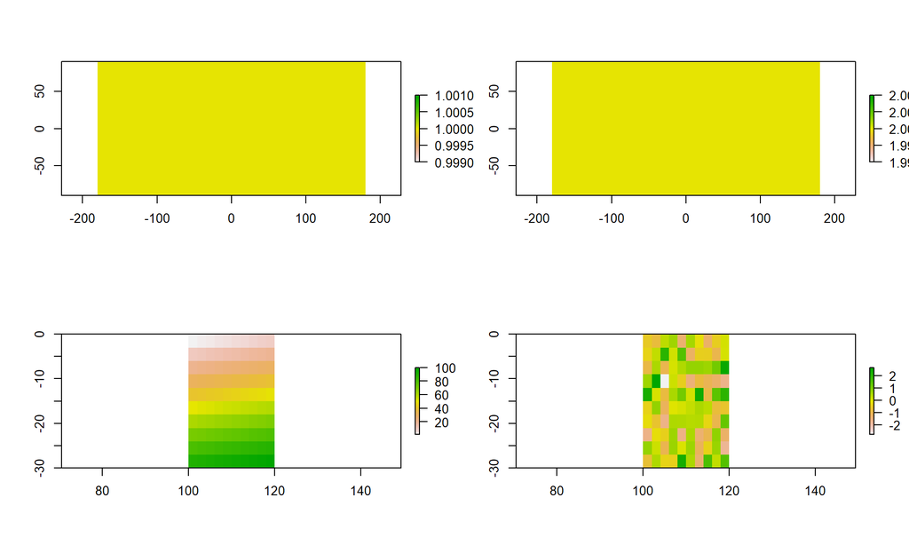

```r
# Basic plot
par(mfrow=c(2,2))
plot(r1a)
plot(r1b)
plot(r2a)
plot(r2b)
```

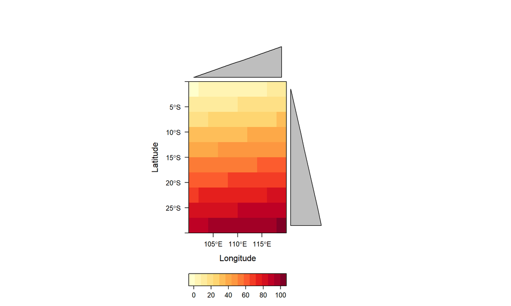

```r
# Nicer plot (using package raterVis)
levelplot(r2a, par.settings=YlOrRdTheme)
```

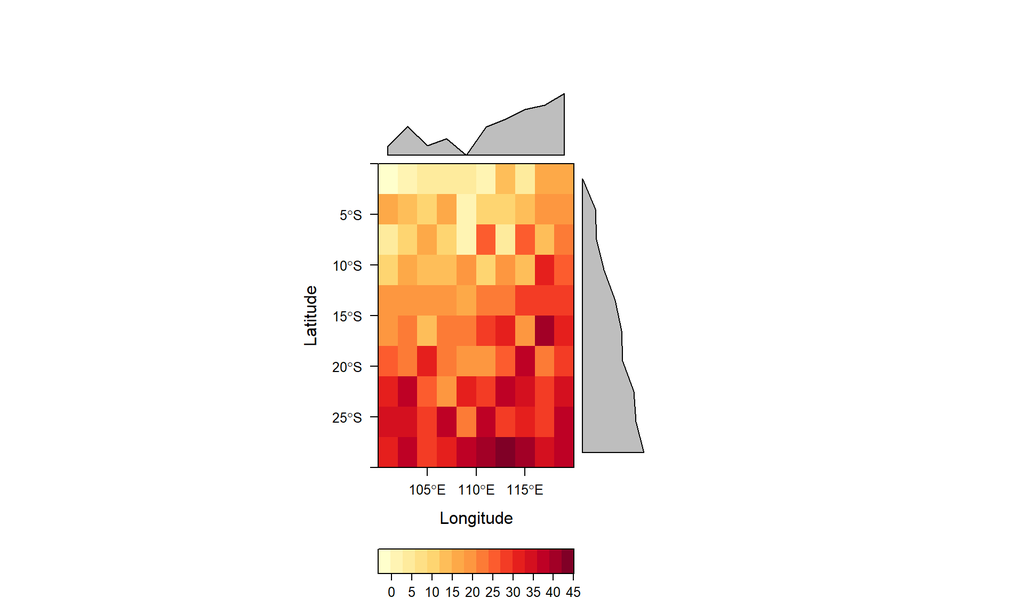

```r
# Plot something more interesting: Latitudinal and Longitudinal gradients, with former 3 times stronger
# Could (should) also implement it using: lapply or mapply
# Used 'for loop' for clarity
for(i in 1:nrow(r2b)) {
    for(j in 1:ncol(r2b)) {
            r2b[i,j]  = 3*i + j + rnorm(n=1, mean=0, sd=5)
    }
}
levelplot(r2b, par.settings=YlOrRdTheme)
```

### 7.2.2 Multi-Layer (RasterStack and RasterBrick) Objects

Works similarly than for single-layer rasters, but for multi-layered rasters all layers are plotted.

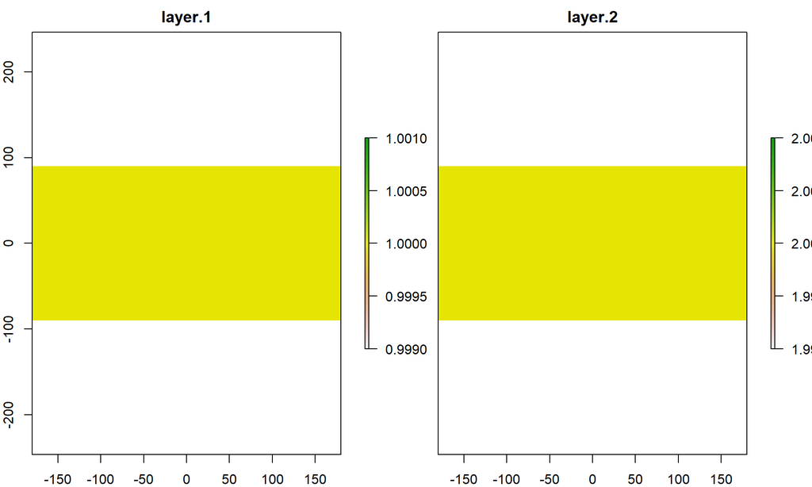

```r
# Basic plot
# par(mfrow=c(2,2))  # 'par': Doesn't work for plotting multi-layer objects.
plot(s1)
```

```r
plot(s2)
```

[output not shown]

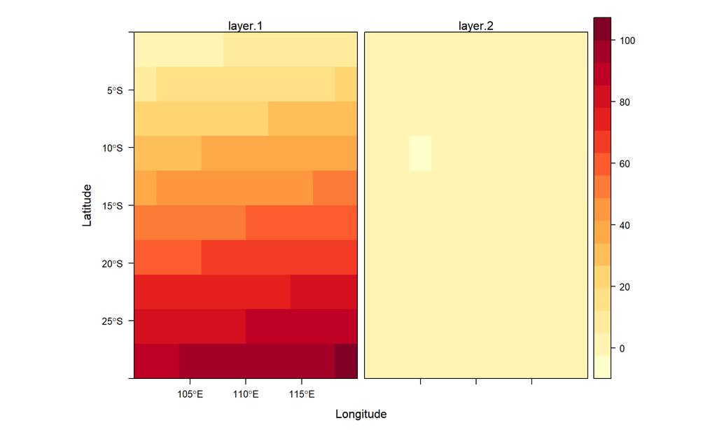

```r
# Nicer plot (using package raterVis)
levelplot(s2, par.settings=YlOrRdTheme)
```